# GGPlot Lecture

Melina Much, Ph.D. Candidate; Mine Dogucu, Ph.D.

8/23/2021

# Why are we plotting?

-Plots are an intuitive way to explore trends in your data, and gain your bearings before starting statistical analysis.

-It also is an invaluable tool for representing your results to others in papers and presentations.

# GGplot: What is it?

- Package for creating visualizations based on the “Grammar of Graphics”
- “Grammar of Graphics” utilized the idea that you can build every graph from the same components: a data set, a coordinate system, and geoms which are visual marks that represent data points
- Part of the tidyverse

# GGplot Basic Intuition

It is a three part process that includes:

- Specifying Data
- Mapping Aesthetics
- Adding a Geometric Layer

# Penguin Data

```r
library(tidyverse)
library(palmerpenguins)
glimpse(penguins)
```

```
## Rows: 344
## Columns: 8
## $ species           <fct> Adelie, Adelie, Adelie, Adelie, Adelie, Adelie, Ade…
## $ island            <fct> Torgersen, Torgersen, Torgersen, Torgersen, Torgers…
## $ bill_length_mm    <dbl> 39.1, 39.5, 40.3, NA, 36.7, 39.3, 38.9, 39.2, 34.1,…
## $ bill_depth_mm     <dbl> 18.7, 17.4, 18.0, NA, 19.3, 20.6, 17.8, 19.6, 18.1,…
## $ flipper_length_mm <int> 181, 186, 195, NA, 193, 190, 181, 195, 193, 190, 18…
## $ body_mass_g       <int> 3750, 3800, 3250, NA, 3450, 3650, 3625, 4675, 3475,…
## $ sex               <fct> male, female, female, NA, female, male, female, mal…
## $ year              <int> 2007, 2007, 2007, 2007, 2007, 2007, 2007, 2007, 200…
```

# Step 1

Add your data layer.

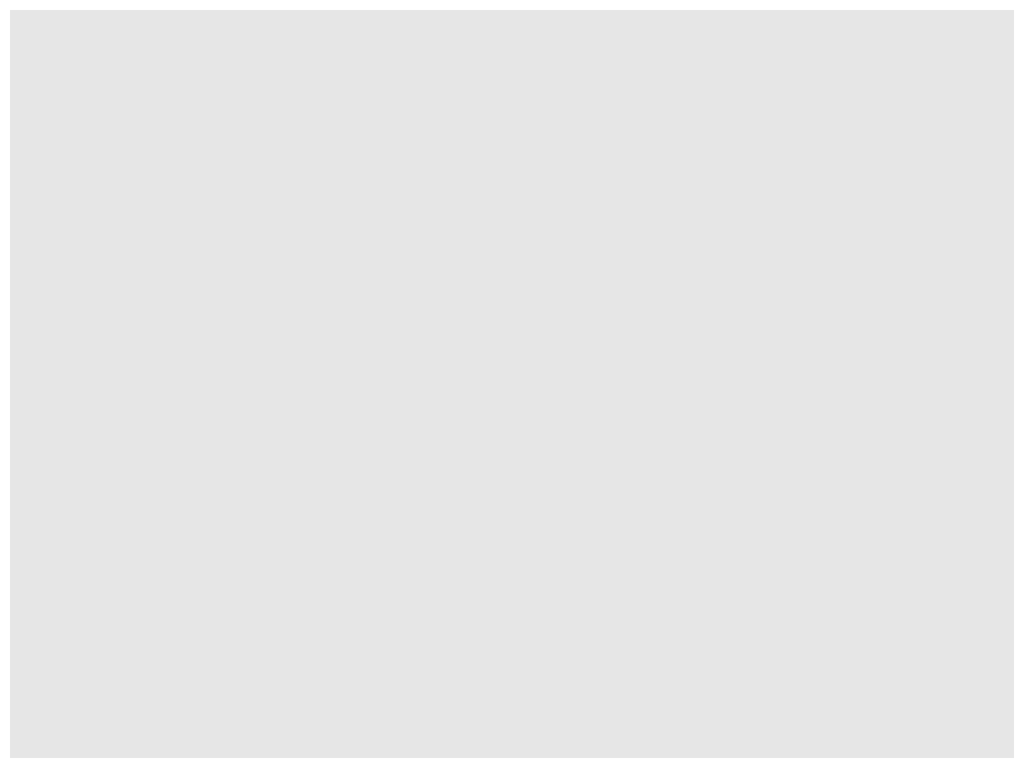

```r
ggplot(data = penguins)
```

# Step 2

Add an aesthetic layer. We are adding an x-axis here.

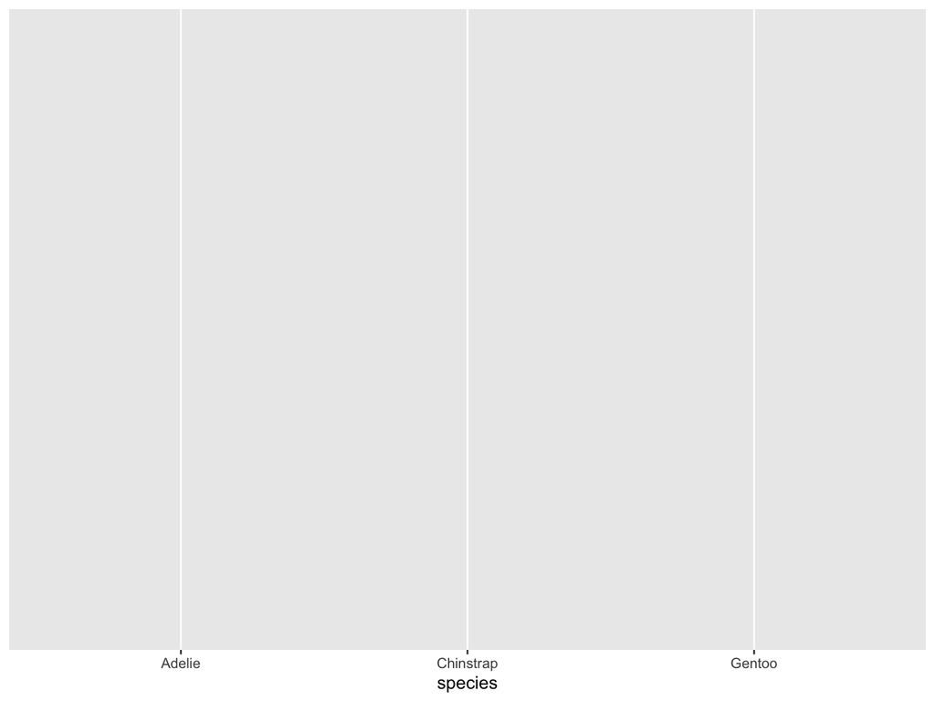

```r
ggplot(data = penguins,
       aes(x = species))
```

# Step 3

Add your geometric layer. We are creating a bar plot for the different penguin species! NOTE! The geometric layer is outside of the parenthesis. It is added outside with an addition sign.

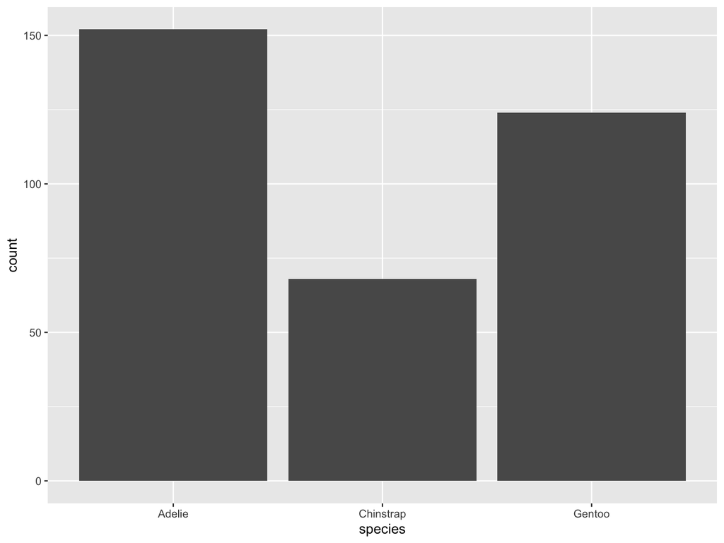

```r
ggplot(data = penguins,
       aes(x = species)) +
        geom_bar()
```

# Plain English Explanation

- Create a ggplot using the penguins data frame.
- Map the species to the x-axis.
- Add a layer of a bar plot.

# Example with Continuous Variable

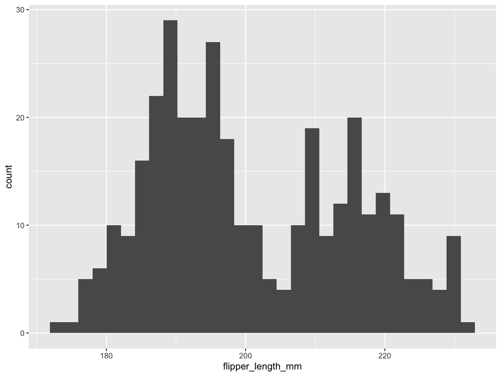

```r
ggplot(data = penguins,
       aes(x = flipper_length_mm)) +
        geom_histogram()
```

# What if we wanted to use a pipe?

Pipes (from the tidyverse) allows us to pass the result of one function/argument to the other one in sequence.

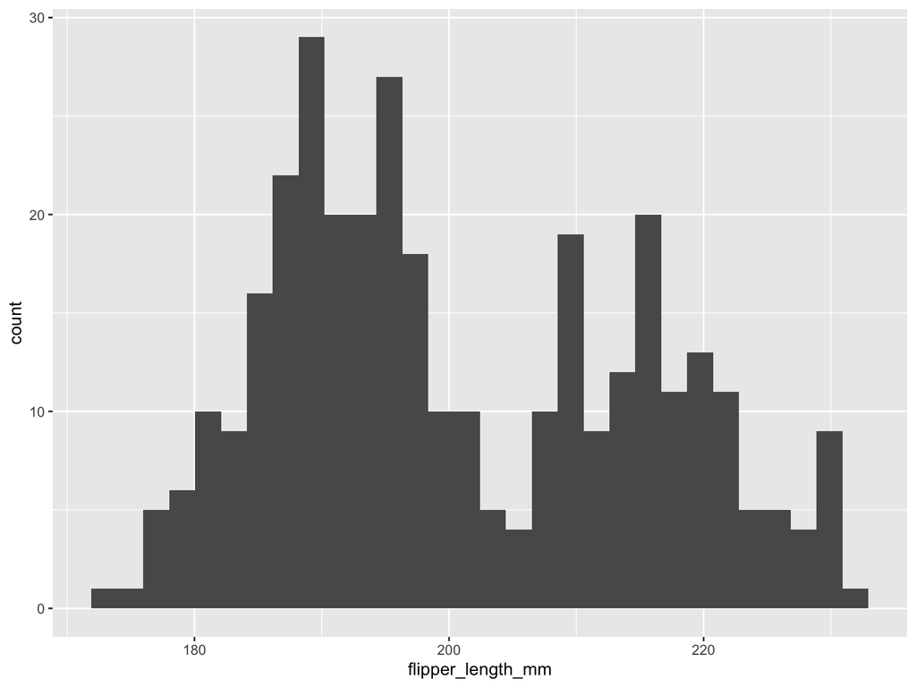

```r
#Note the warning!
penguins %>%
ggplot(aes(x = flipper_length_mm)) +
        geom_histogram()
```

[output not shown]

# Lets play with color!

- Color and pipes! We can do it all. You can find more colors [here](http://www.stat.columbia.edu/~tzheng/files/Rcolor.pdf).
- Please note certain color palettes are less accessible than others. This palette is the default, and is less accessible to those who are red-green color blind.

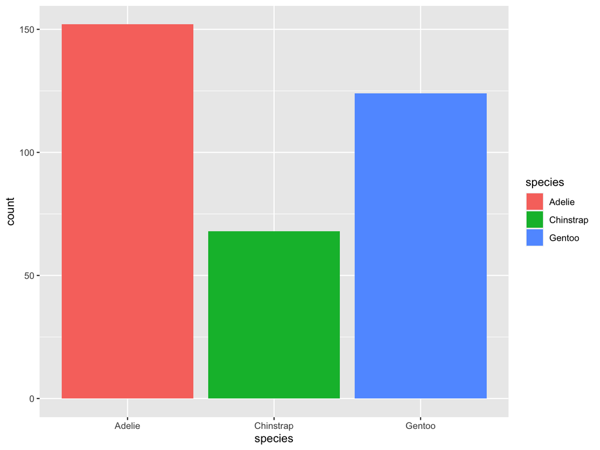

```r
penguins %>%
ggplot(aes(x = species, fill = species)) +
        geom_bar()
```

# Two Variable Visualization - Categorical

Lets make two.

The first is our standard bar chart, and lets add color for which island the penguin is from.

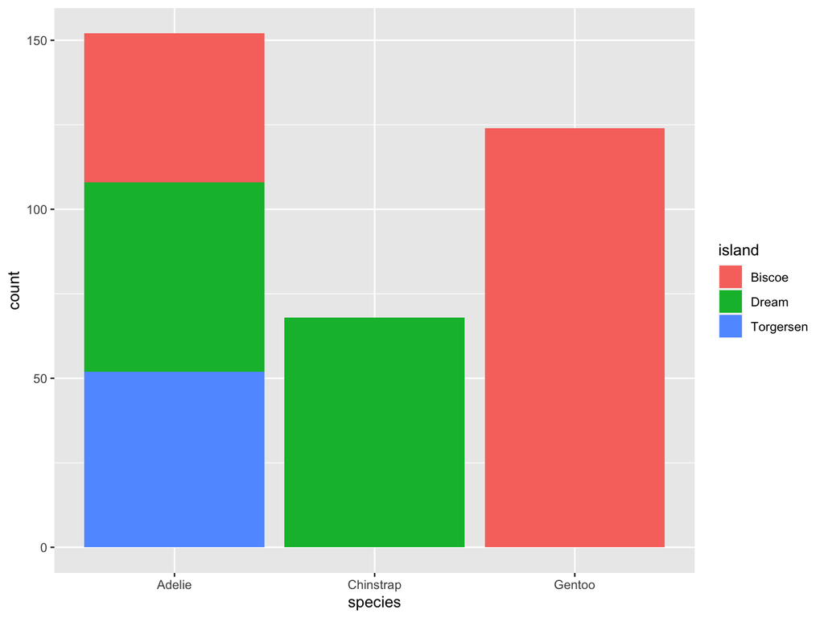

```r
penguins %>%
ggplot(aes(x = species, fill = island)) +
        geom_bar()
```

# Cont.

The second, we will make a standardized bar chart, which makes the total bar be out of 1. This allows us to look at proportions easily! *Note the additional ylab layer.*

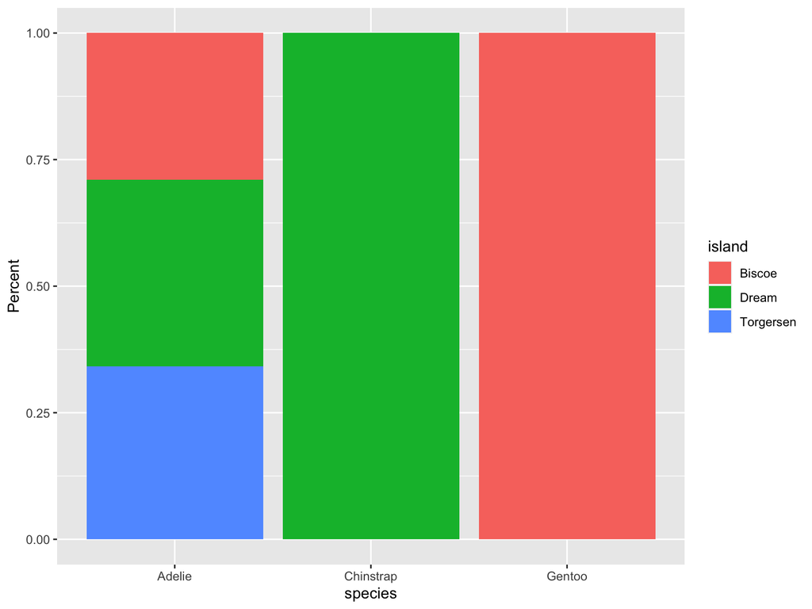

```r
penguins %>%
ggplot(aes(x = species, fill = island)) +
        ylab("Percent") +
        geom_bar(position = "fill")
```

# Two Variables - Continuous & Categorical

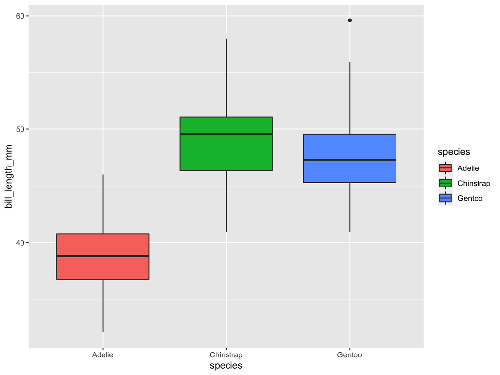

```r
penguins %>%
ggplot(aes(x = species,
           y = bill_length_mm, fill = species))  +
  geom_boxplot()
```

# Two Variables - All Continuous Numeric!

Lets look at bill length and depth!

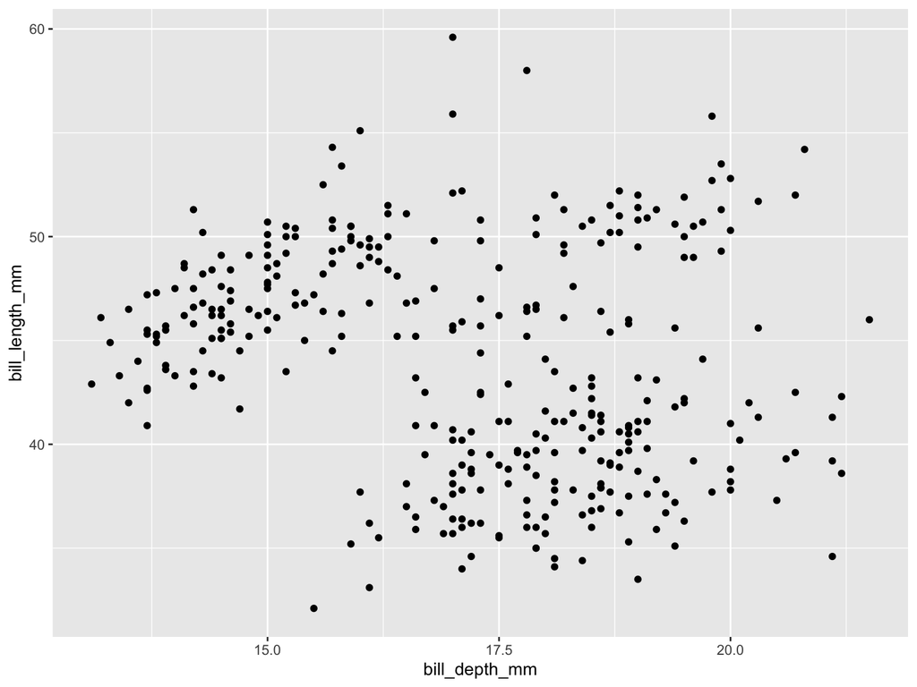

```r
penguins %>%
ggplot(aes(x = bill_depth_mm,
           y = bill_length_mm))  +
  geom_point()
```

# Three Variables! Wow!

Note we are adding a color argument as a third variable (species).

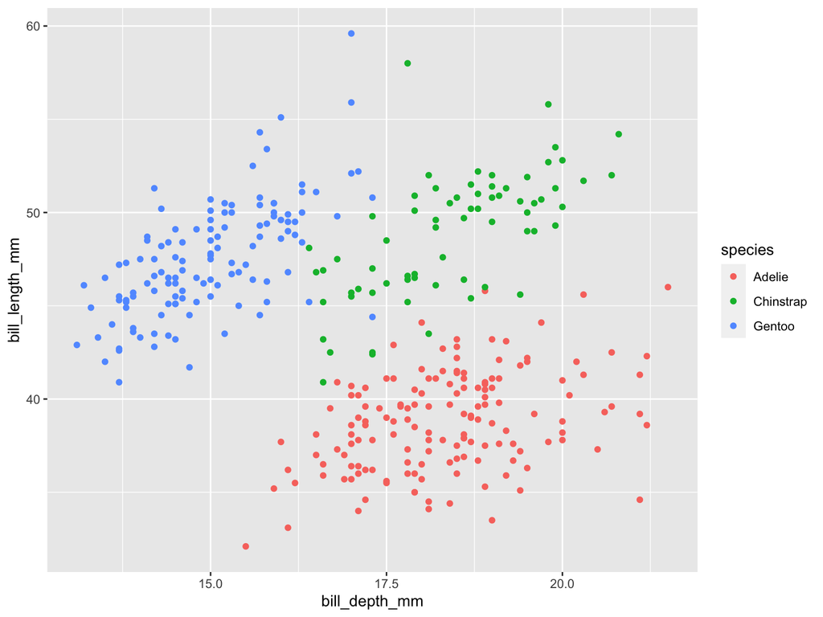

```r
ggplot(penguins,
       aes(x = bill_depth_mm,
           y = bill_length_mm,
           color = species)) +
  geom_point()
```

# Hmmm…Can we use something other than dots?

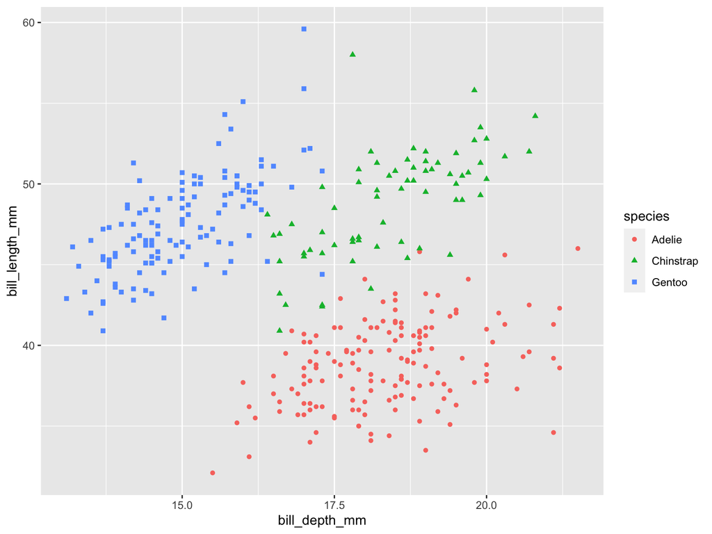

```r
penguins %>%
ggplot(aes(x = bill_depth_mm,
           y = bill_length_mm,
           shape = species,
           color = species)) +
  geom_point()
```

# Lets make it *really* easy!

We want to start you off with mosaic as well. While we feel confident in your ability to learn GGplot code, we also want you to have an intuitive way to get yourself started in your own projects.

Mosaic does just that. It provides a point and click interface to select variables and kinds of plots, while also returning ggplot code so you can see what it did.

```r
#library(mosaic)

#mplot(penguins)
```

# Cheet Sheet

GGplot cheat [sheet](https://www.maths.usyd.edu.au/u/UG/SM/STAT3022/r/current/Misc/data-visualization-2.1.pdf).